# Wine quality EDA

today

## Wine EDA

**Import the dataset into R**  
There are 1599 observations of red-wine and 4898 observations of white-wine

```r
wine_red <- data.frame(read.csv("./dataset/winequality-red.csv",sep = ";"))
wine_white <- data.frame(read.csv("./dataset/winequality-white.csv",sep = ";"))
summary(wine_red)
summary(wine_white)
str(wine_red)
str(wine_white)
#wine = read.csv("/Users/nischaysaicherukuri/Downloads/wine-quality-white-and-red.csv")
```

[output not shown]

Combine the two datasets into one

```r
wine_red['category'] = "red"
wine_white['category'] = "white"
wine <- rbind(wine_red,wine_white)
```

Take a look if there is null and na values

```r
colSums(is.na(wine))
```

[output not shown]

## EDA Analysis

First,let’s take a look of the quality distrubution between white and red wine.

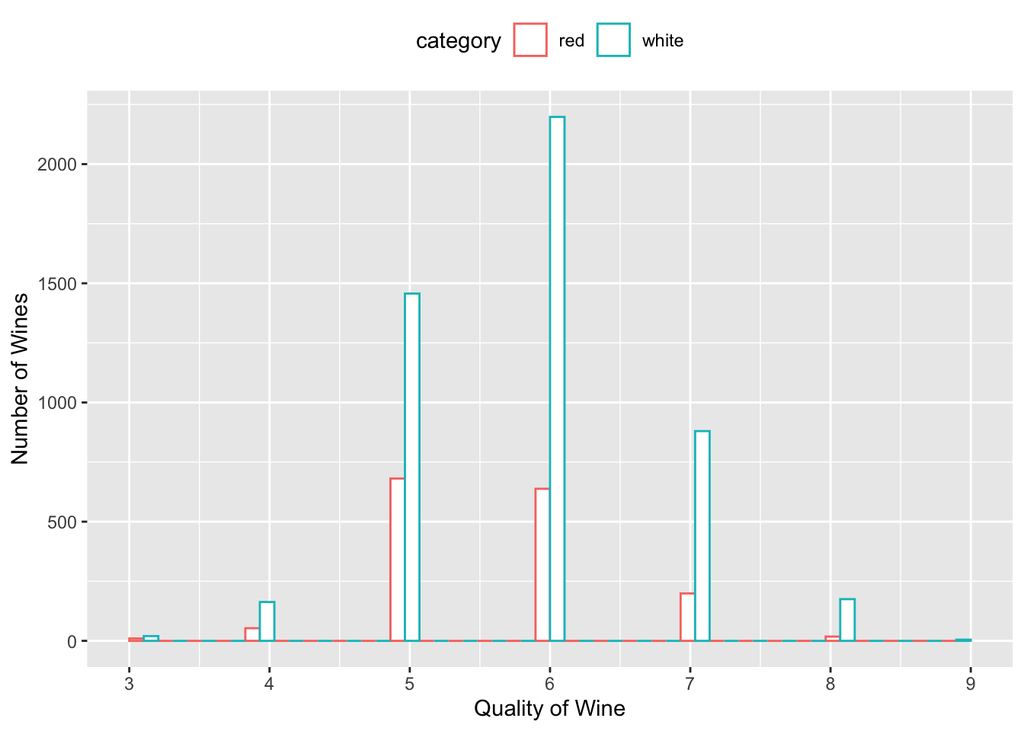

```r
unique(wine$quality)
table(wine$quality)
table(wine_white$quality)
library(ggplot2)
ggplot(wine, aes(x=quality, color=category)) +
  geom_histogram(fill="white", position="dodge")+
  scale_x_continuous(limits = c(3, 9), breaks = seq(3, 9, 1)) +
  theme(legend.position="top")+
  xlab('Quality of Wine') +
  ylab('Number of Wines')
```

Secondly, we would like to see how each independent variables differ from white and red wine. 1. fixed.acidity

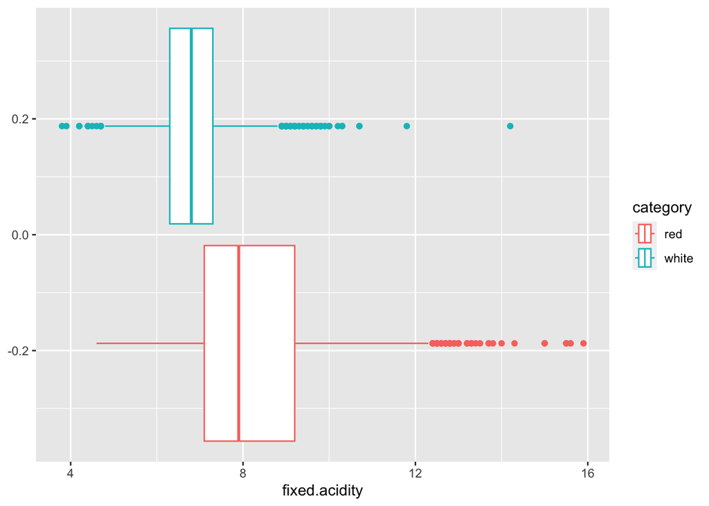

```r
ggplot(wine, aes(x=fixed.acidity, color=category)) +
  geom_boxplot()
```

2. volatile.acidity

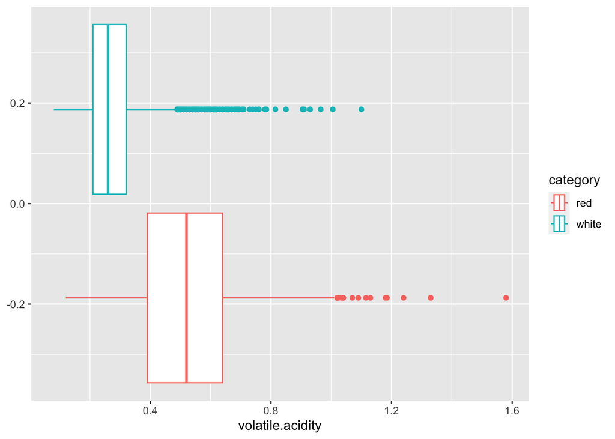

```r
ggplot(wine, aes(x=volatile.acidity, color=category)) +
  geom_boxplot()
```

3.citric.acid

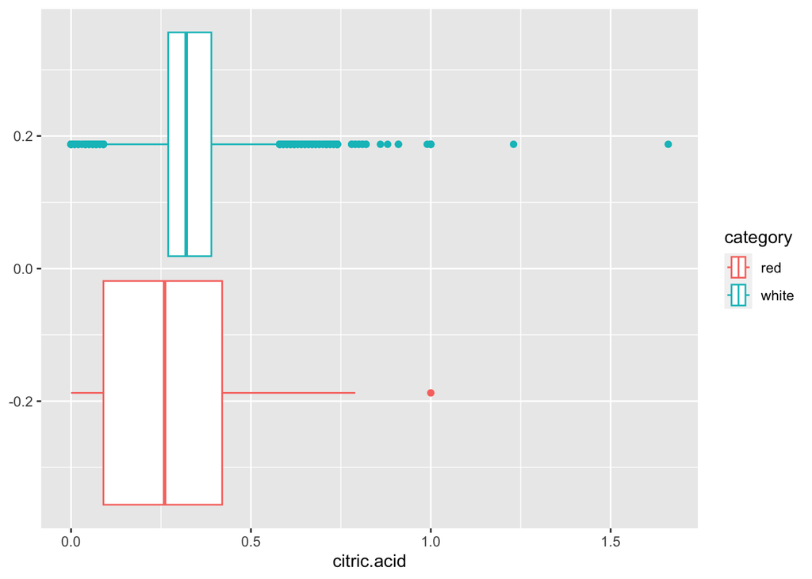

```r
ggplot(wine, aes(x=citric.acid, color=category)) +
  geom_boxplot()
```

4.residual.sugar

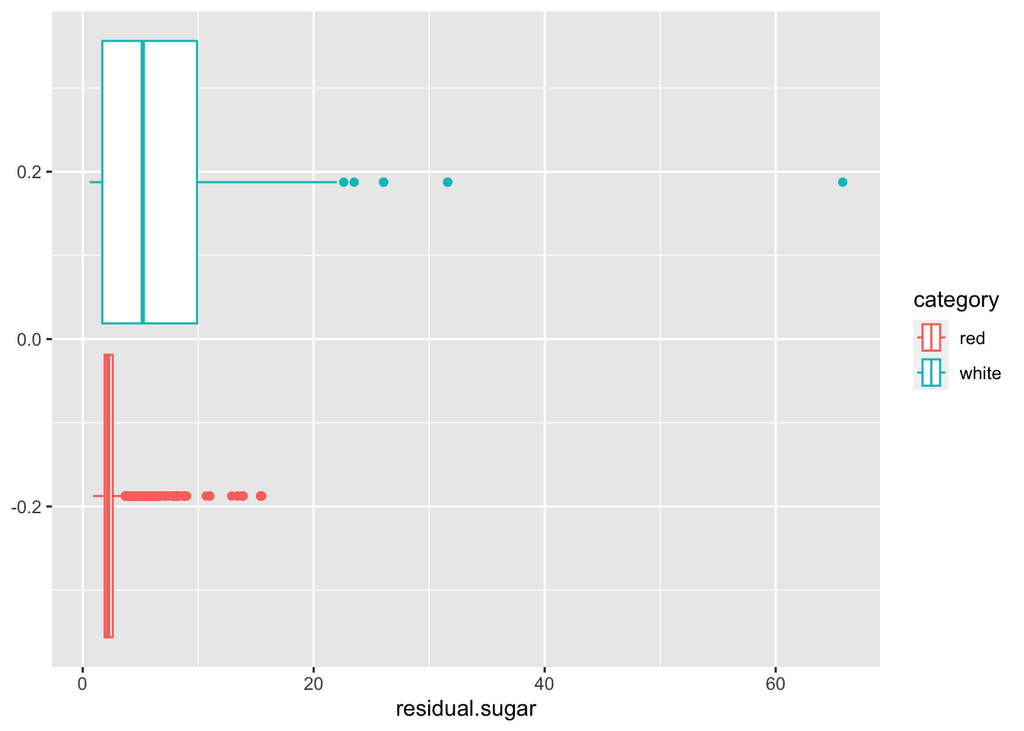

```r
ggplot(wine, aes(x=residual.sugar, color=category)) +
  geom_boxplot()
```

5.chlorides

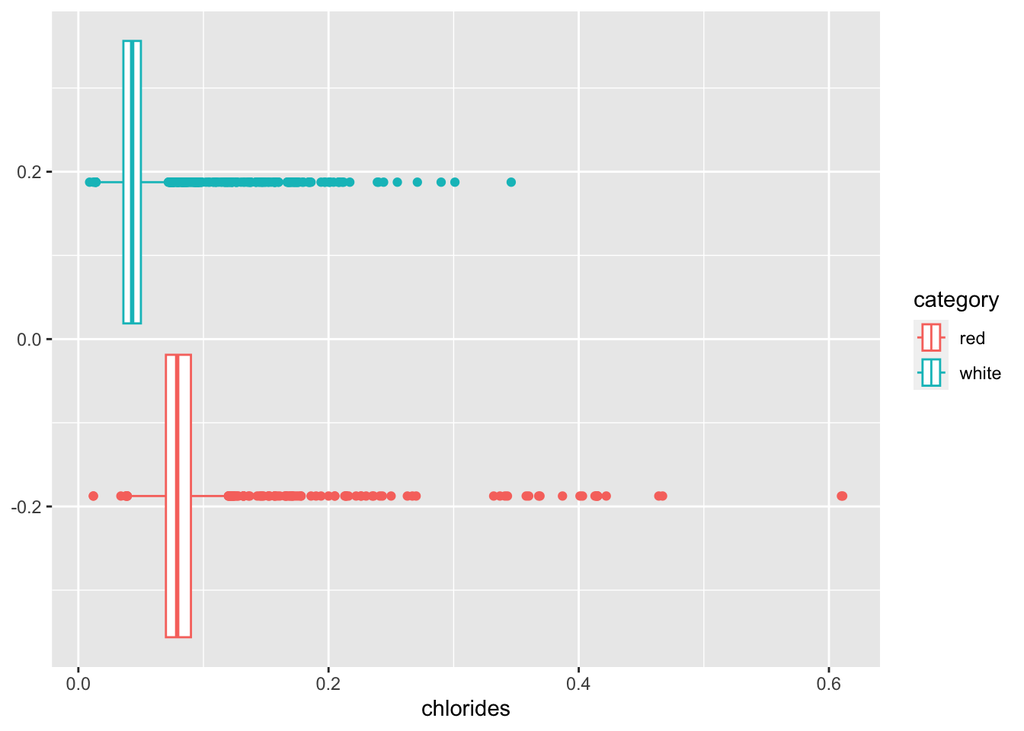

```r
ggplot(wine, aes(x=chlorides, color=category)) +
  geom_boxplot()
```

6.free.sulfur.dioxide

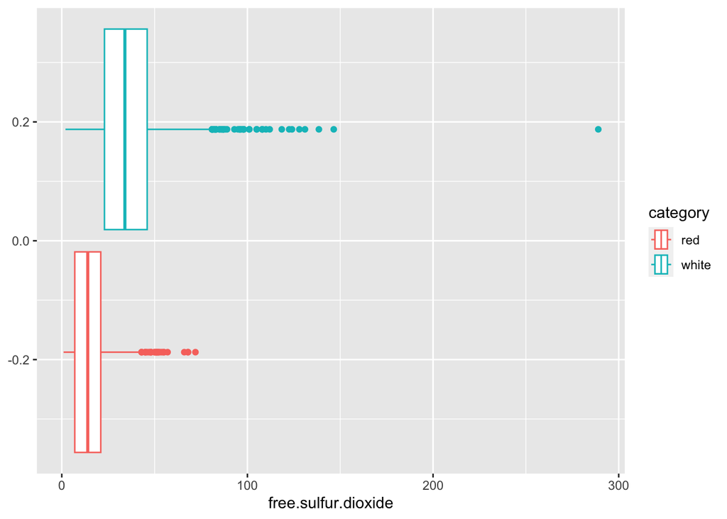

```r
ggplot(wine, aes(x=free.sulfur.dioxide, color=category)) +
  geom_boxplot()
```

7.total.sulfur.dioxide

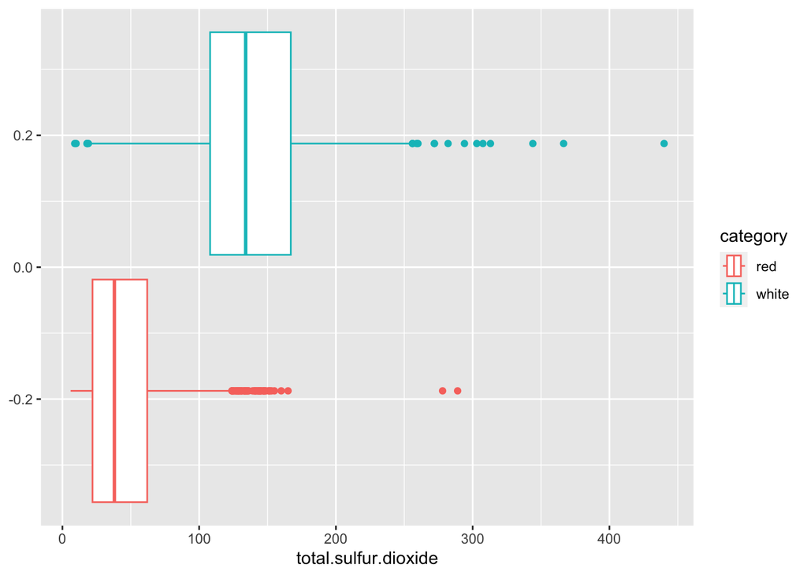

```r
ggplot(wine, aes(x=total.sulfur.dioxide, color=category)) +
  geom_boxplot()
```

8.density

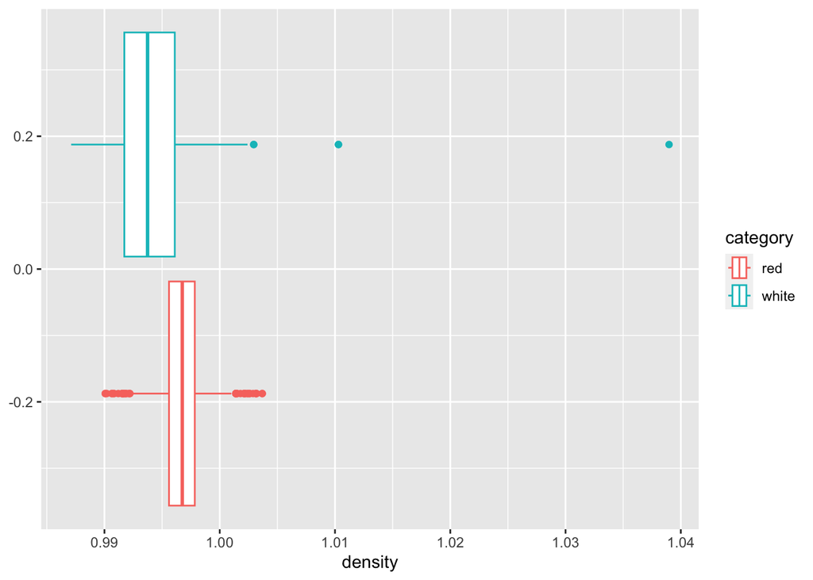

```r
ggplot(wine, aes(x=density, color=category)) +
  geom_boxplot()
```

9.pH

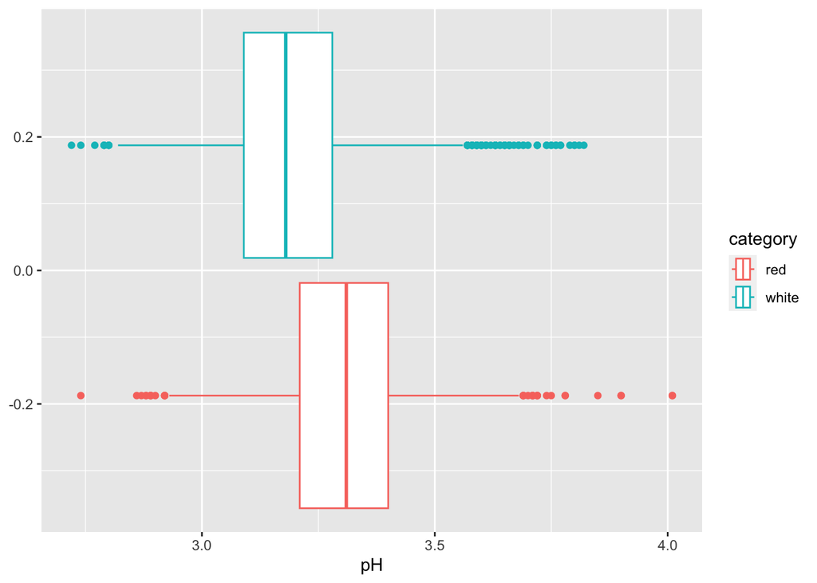

```r
ggplot(wine, aes(x=pH, color=category)) +
  geom_boxplot()
```

10.sulphates

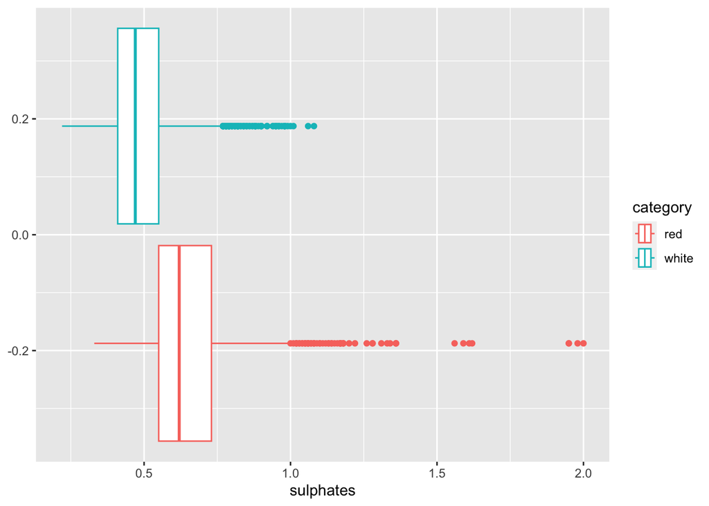

```r
ggplot(wine, aes(x=sulphates, color=category)) +
  geom_boxplot()
```

11.alcohol

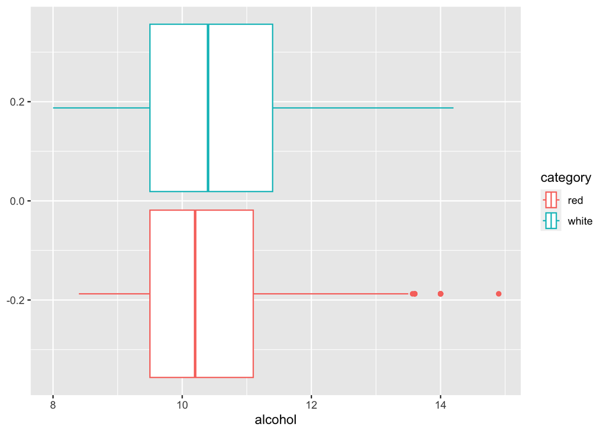

```r
ggplot(wine, aes(x=alcohol, color=category)) +
  geom_boxplot()
```

From the boxplots, we can see that the variation is differed significantly in following variables: fixed.acidity residual.sugar total.sulfur.oxide free.sulfur.dioxide chlorides volatile.acidity

## Testing

Now, let’s take a look on correlation between each variable

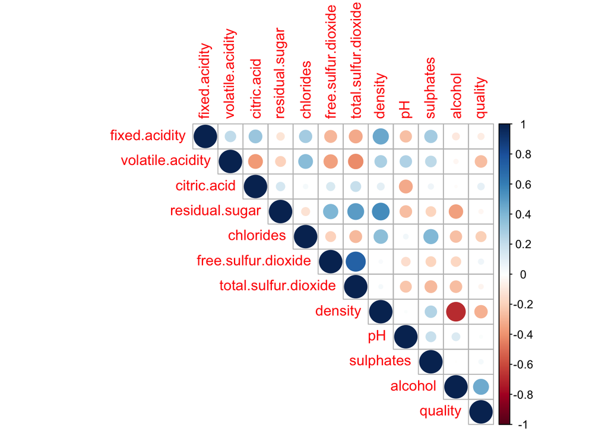

```r
loadPkg("corrplot")
#wine_noca_red = subset(wine_red, select = -c(category) )
#wine_noca_redcor = cor(wine_noca_red )
#corrplot(wine_noca_redcor,type="upper")

#wine_noca_white = subset(wine_white, select = -c(category) )
#wine_noca_whitecor = cor(wine_noca_white)
#corrplot(wine_noca_whitecor,type="upper")

wine_noca = subset(wine, select = -c(category) )
wine_nocacor = cor(wine_noca )
corrplot(wine_nocacor,type="upper")
```

As we can see from the correlation diagram, the below variables are mostly corrleated to the quality. And we would like to dig further to see the effect quality vs alcohol quality vs density quality vs volatile.acidity quality vs chlorides

We would anaysis in follwing steps: 1. normality test - qq plot & histagram 2. correlation test 3. scatter plot&boxplot- check the relationship 4. Annova test - compare means of our attribute across the wines and check if differences are statistically significant compared to the quality of a wine.

1.quality vs alcohol The distribution of alcohol data is right skewed

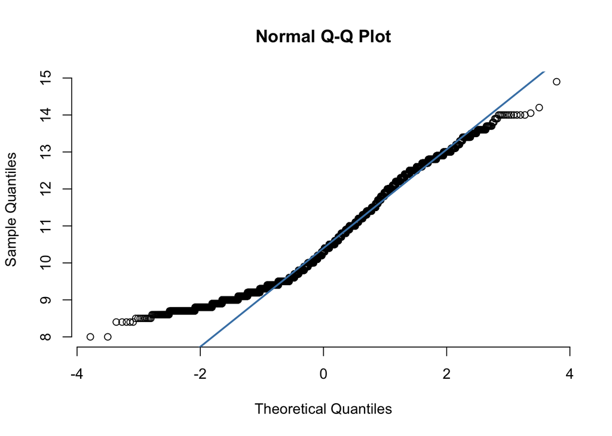

```r
qqnorm(wine$alcohol, pch = 1, frame = FALSE)
qqline(wine$alcohol, col = "steelblue", lwd = 2)
```

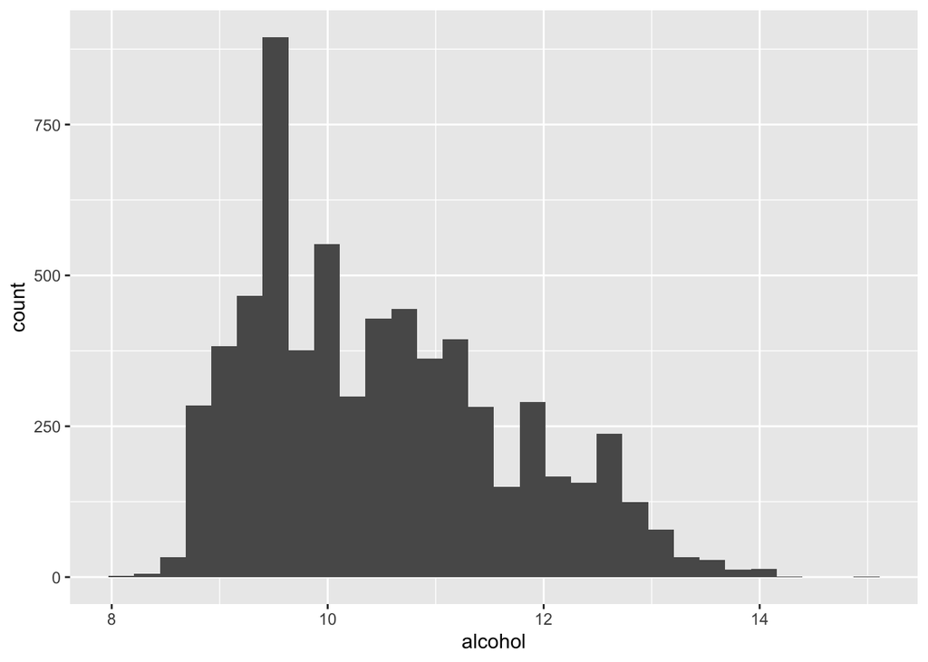

```r
ggplot(wine, aes(x=alcohol)) + geom_histogram()
```

```r
cor.test(wine$alcohol,wine$quality)
```

[output not shown]

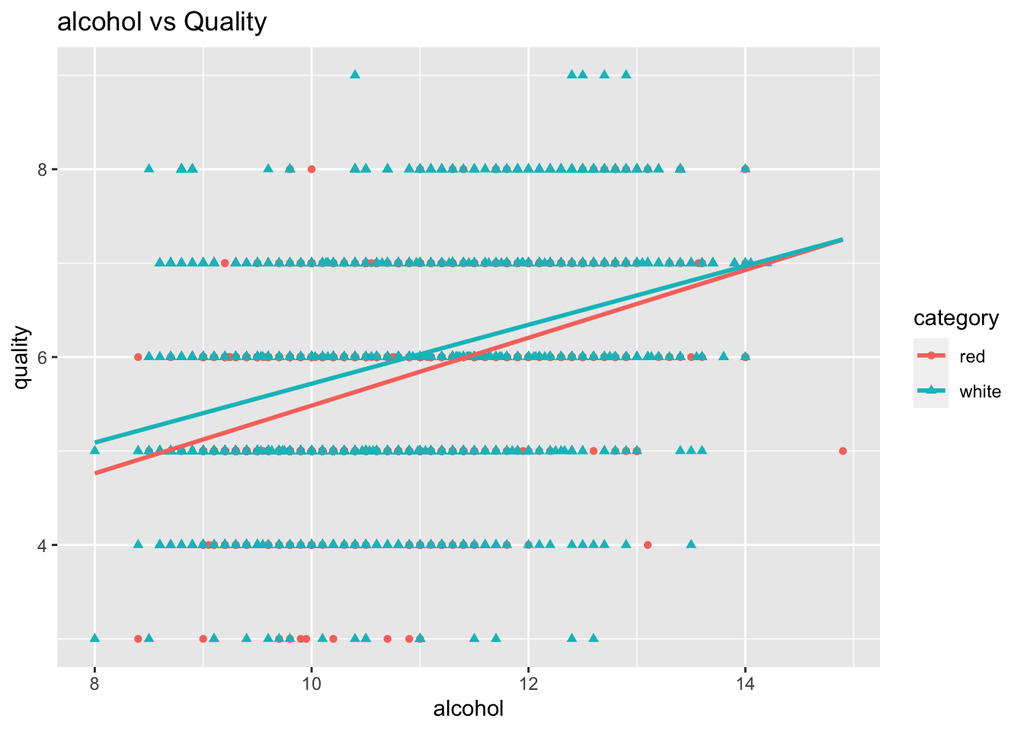

```r
ggplot(wine, aes(x=alcohol, y=quality, color=category, shape = category)) +
  geom_point() +
  geom_smooth(method=lm, se=FALSE, fullrange=TRUE)+
  ggtitle("alcohol vs Quality")
```

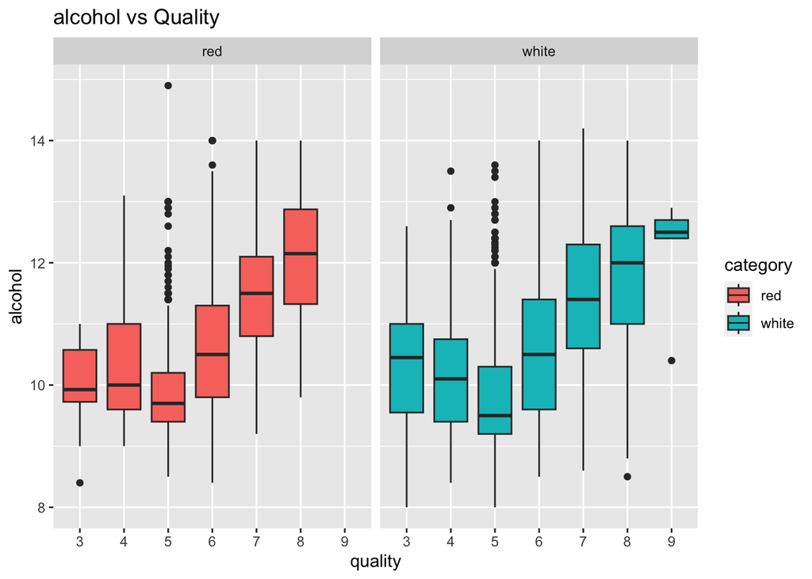

```r
wine_cat <- wine
wine_cat$quality <- factor(wine_cat$quality)
ggplot(wine_cat, aes(x=quality, y=alcohol, fill=category)) +
    geom_boxplot() +
    facet_wrap(~category)+
    ggtitle("alcohol vs Quality")
```

```r
anova_alcohol = aov(alcohol ~ quality, data=wine_cat)
summary(anova_alcohol)
```

[output not shown]

2.quality vs density Density plot looks normally distributed

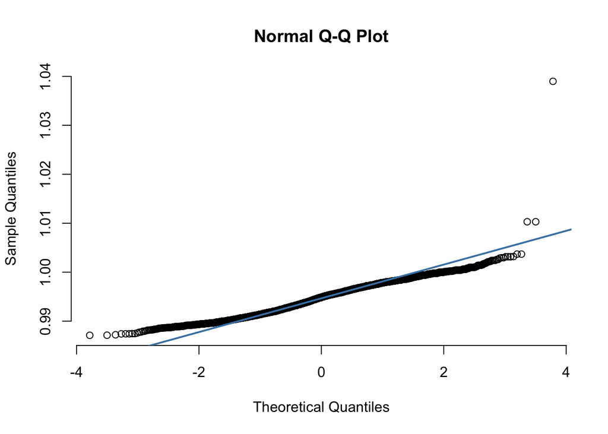

```r
qqnorm(wine$density, pch = 1, frame = FALSE)
qqline(wine$density, col = "steelblue", lwd = 2)
```

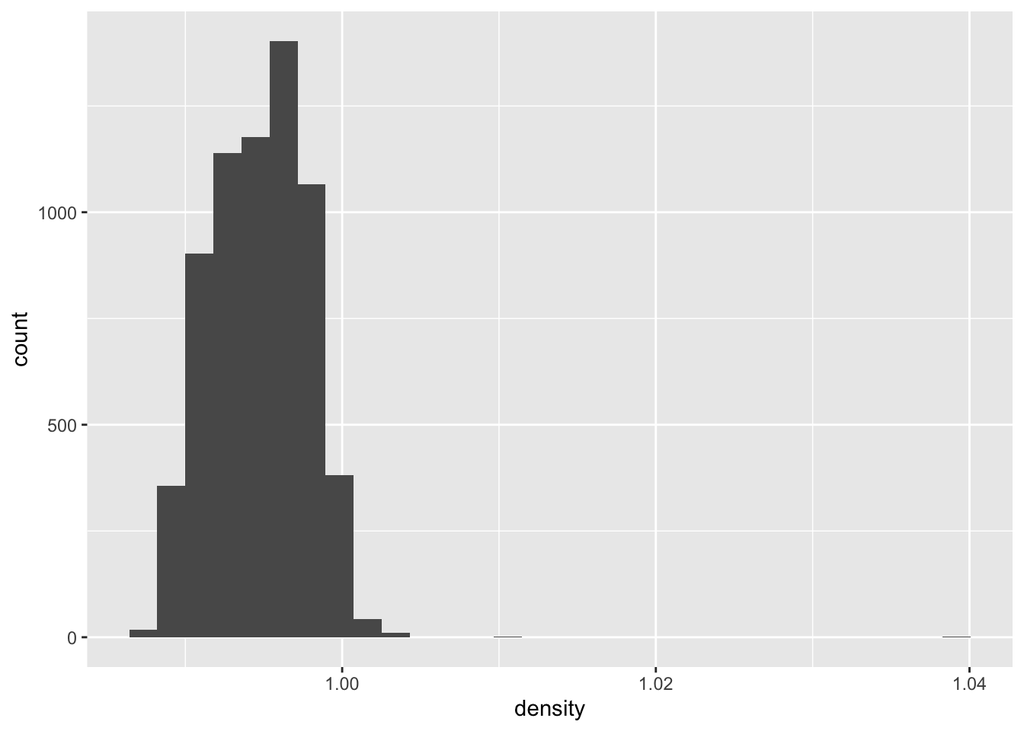

```r
ggplot(wine, aes(x=density)) + geom_histogram()
```

```r
cor.test(wine$density,wine$quality)
```

[output not shown]

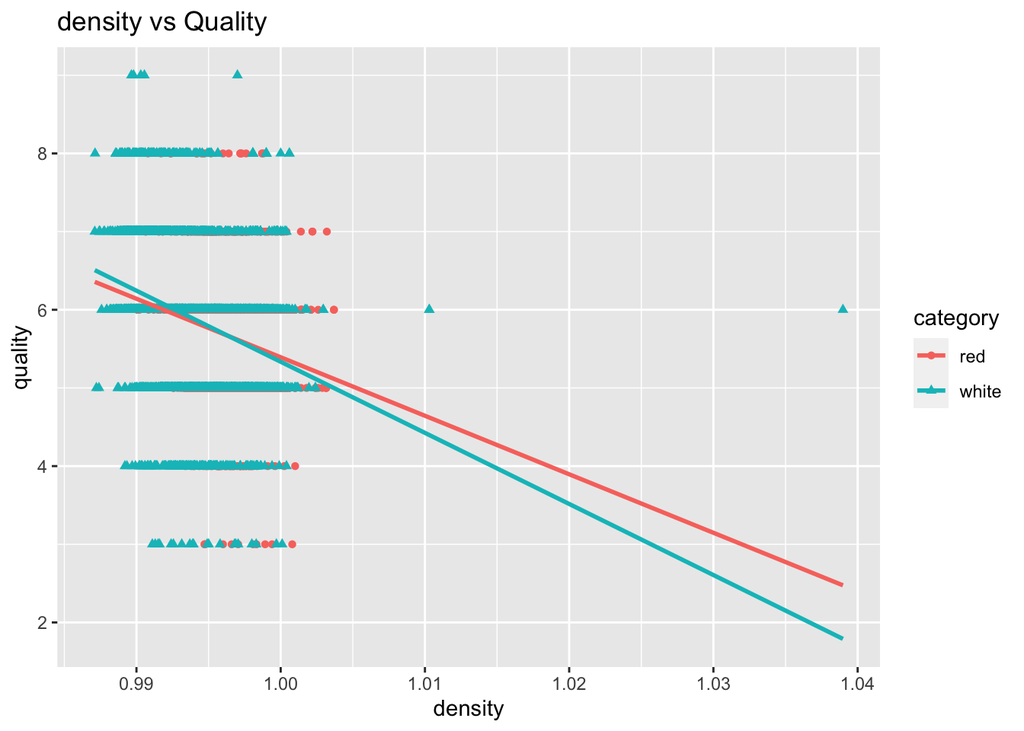

```r
ggplot(wine, aes(x=density, y=quality, color=category, shape = category)) +
  geom_point() +
  geom_smooth(method=lm, se=FALSE, fullrange=TRUE)+
  ggtitle("density vs Quality")
```

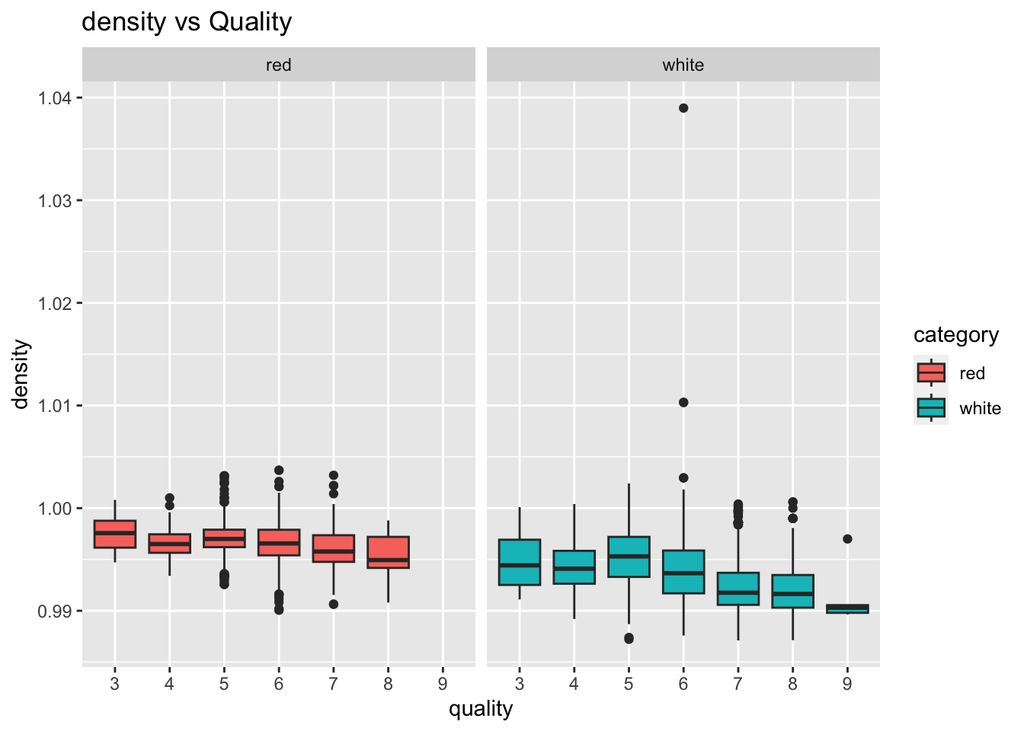

```r
ggplot(wine_cat, aes(x=quality, y=density, fill=category)) +
    geom_boxplot() +
    facet_wrap(~category)+
    ggtitle("density vs Quality")
```

```r
anova_density = aov(density ~ quality, data=wine_cat)
summary(anova_density)
```

[output not shown]

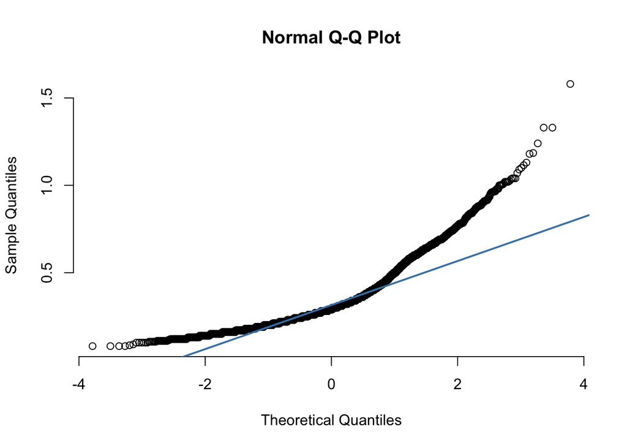

```r
qqnorm(wine$volatile.acidity, pch = 1, frame = FALSE)
qqline(wine$volatile.acidity, col = "steelblue", lwd = 2)
```

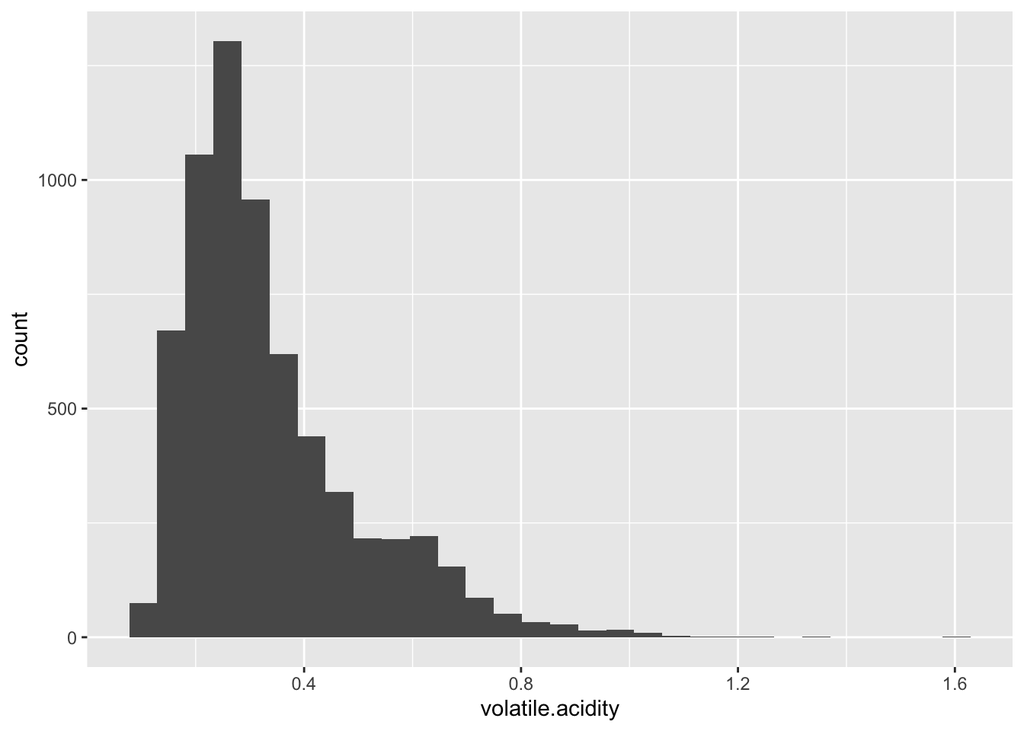

```r
ggplot(wine, aes(x=volatile.acidity)) + geom_histogram()
```

```r
cor.test(wine$volatile.acidity,wine$quality)
```

[output not shown]

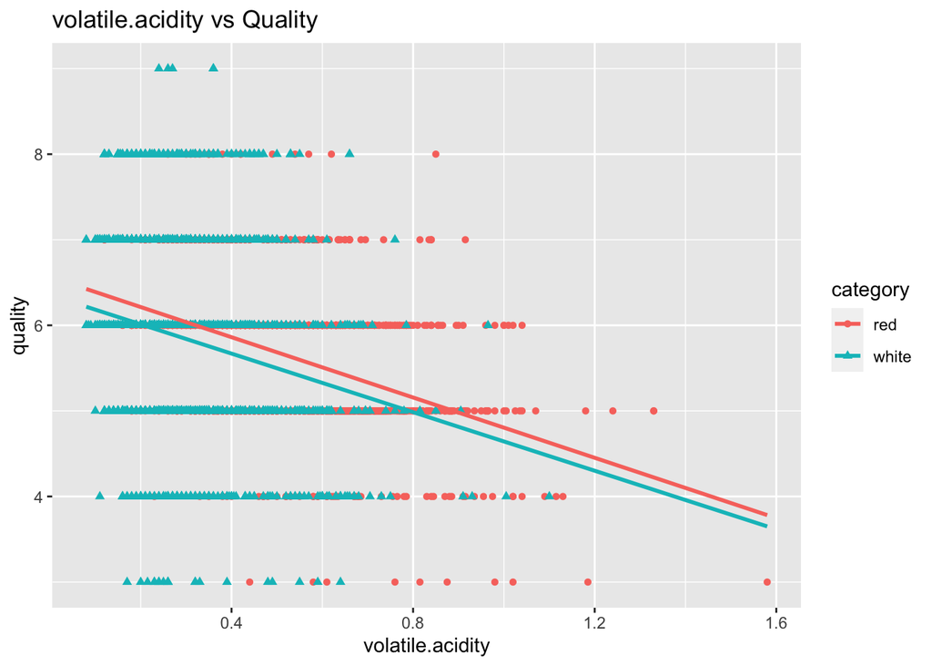

```r
ggplot(wine, aes(x=volatile.acidity, y=quality, color=category, shape = category)) +
  geom_point() +
  geom_smooth(method=lm, se=FALSE, fullrange=TRUE)+
  ggtitle("volatile.acidity vs Quality")
```

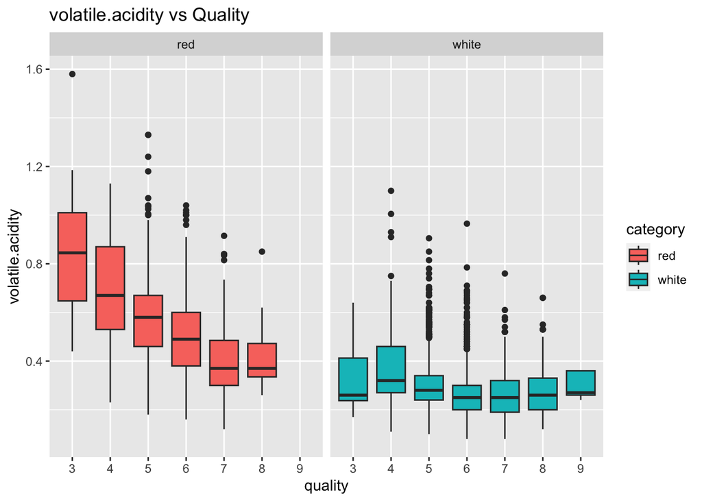

```r
ggplot(wine_cat, aes(x=quality, y=volatile.acidity, fill=category)) +
    geom_boxplot() +
    facet_wrap(~category)+
    ggtitle("volatile.acidity vs Quality")
```

```r
anova_volatile.acidity = aov(volatile.acidity ~ quality, data=wine_cat)
summary(anova_volatile.acidity)
```

[output not shown]

[figure not shown]

```r
qqnorm(wine$density, pch = 1, frame = FALSE)
qqline(wine$density, col = "steelblue", lwd = 2)
```

[figure not shown]

```r
ggplot(wine, aes(x=density)) + geom_histogram()
```

```r
cor.test(wine$density,wine$quality)
```

[output not shown]

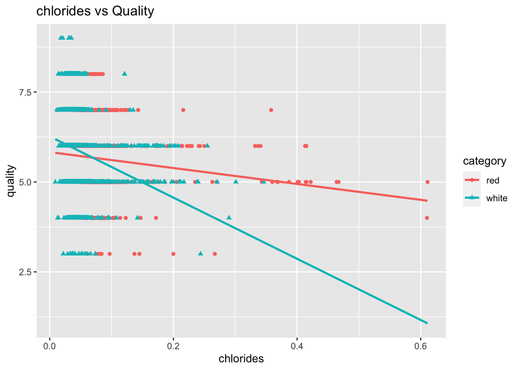

```r
ggplot(wine, aes(x=chlorides,y=quality, color=category, shape = category)) +
  geom_point() +
  geom_smooth(method=lm, se=FALSE, fullrange=TRUE)+
  ggtitle("chlorides vs Quality")
```

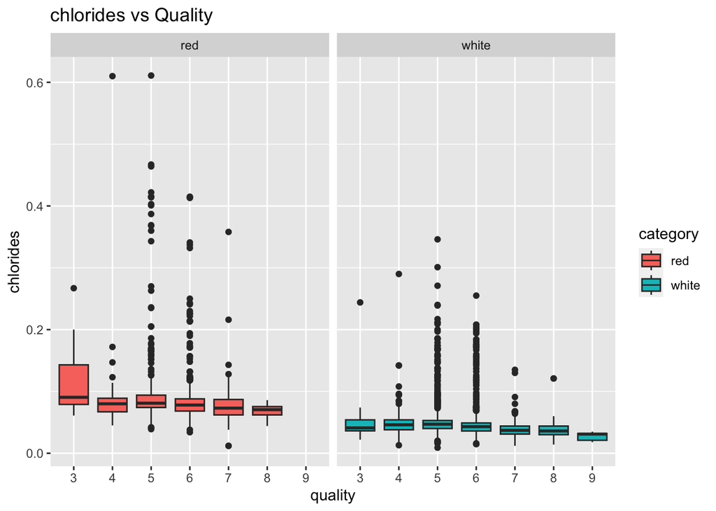

```r
ggplot(wine_cat, aes(x=quality, y=chlorides, fill=category)) +
    geom_boxplot() +
    facet_wrap(~category)+
    ggtitle("chlorides vs Quality")
```

```r
anova_chlorides = aov(chlorides ~ quality, data=wine_cat)
summary(anova_chlorides)
```

[output not shown]